# Machine Learning

## *Machine Learning* introduction

Nous allons apprendre via un exemple concret les bases du Machine Learning. Pour cela, il faut télécharger les données d’entraînement et les sorties d'apprentissages.

**Plan du Tp :**

- Compréhension et problématique du sujet
- Etape de *Data mining*
  - Etape *d'éxploaration* des données
    - *textuelle* ou *graphique* des données
- Etape de *modélisation* statisques
  - Etape de *vérification* de la perfomance du modèle
- Etape de restitution des résultats

### Problématique : Titanic

Le but est de créer un modèle statistique (machine learning) de chance de survie d'un passager du Titanic en fonction de plusieurs variables explicatives.

La première étape est de bien cerner la problématique du sujet à modéliser. Dans notre cas, nous disposons de données d'entraînement ainsi que des données supplémentaires afin de tester notre modèle. Après, il est possible de faire une recherches bibliographiques afin de créer de nouvelles variables ou de récupérer plus de données.

## - www.allocine.fr/video/player_gen_cmedia=19263225&cfilm=5818.html

### Première étape le data mining

Il s’agit de télécharger vos données et de les insérer dans R via les nombreuses commandes graphiques ou consoles, que vous apprises dans le cours de Master 1. Il s’agit de rappels, je vous recommande d’écrire un script afin de ne pas perdre vos données et surtout de rendre votre code reproductible et de ne pas perdre vos données. Puis, il faut contrôler les données que vous avez téléchargées.

**Question** Télécharger les données sur le répertoire github du cours, soit via le terminal avec ces commandes :

`git clone "url_du_dossier_github"`

ou si vous l'avez déjà fait allez dans votre répertoire du premier cours

`git fetch -a`

`git pull`

Autrement, via la façon graphique vous pouvez accéder au site de https://github.com/LaurentPolitis/data_science_intro/tree/master/data

Les données d'entraînement doit être utilisé pour construire votre modéle de machine learning. Pour le jeux de données d'entraînement, il comprend des variables tels que la réponse au problème (c'est à dire la survie du passager à la catastrophe), le nom du passager, le genre, le numéro de cabine. Le modèle va s'appuyer sur ces variables explicatives. Vous pouvez en créer d'autre.

```r
library("ggplot2") # visualisation
library("dplyr") #  manipulation
library("randomForest") # classification algorithme
# lire les données sous R
train <- read.csv("~//Documents//R//Cours2019_M2//data//train.csv", stringsAsFactors = F)
#test  <- read.csv("~//Documents//R//Cours2019_M2//data//test.csv", stringsAsFactors = F)
#train$type <- "test"
# vérifier les données
#full  <- bind_rows(train, test) #
```

**Question** Explorer le type de la data frame que vous venez de télécharger ? Combien d'observations sont contenues dans cette data frame ? Combien de variables sont présentes dans cette data frame ?

```r
str(train)
```

```
'data.frame':	891 obs. of  12 variables:
 $ PassengerId: int  1 2 3 4 5 6 7 8 9 10 ...
 $ Survived   : int  0 1 1 1 0 0 0 0 1 1 ...
 $ Pclass     : int  3 1 3 1 3 3 1 3 3 2 ...
 $ Name       : chr  "Braund, Mr. Owen Harris" "Cumings, Mrs. John Bradley (Florence Briggs Thayer)" "Heikkinen, Miss. Laina" "Futrelle, Mrs. Jacques Heath (Lily May Peel)" ...
 $ Sex        : chr  "male" "female" "female" "female" ...
 $ Age        : num  22 38 26 35 35 NA 54 2 27 14 ...
 $ SibSp      : int  1 1 0 1 0 0 0 3 0 1 ...
 $ Parch      : int  0 0 0 0 0 0 0 1 2 0 ...
 $ Ticket     : chr  "A/5 21171" "PC 17599" "STON/O2. 3101282" "113803" ...
 $ Fare       : num  7.25 71.28 7.92 53.1 8.05 ...
 $ Cabin      : chr  "" "C85" "" "C123" ...
 $ Embarked   : chr  "S" "C" "S" "S" ...
```

```r
head(train)
```

| PassengerId | Survived | Pclass | Name | Sex | Age | SibSp | Parch | Ticket | Fare | Cabin | Embarked |
| --- | --- | --- | --- | --- | --- | --- | --- | --- | --- | --- | --- |
| 1 | 0 | 3 | Braund, Mr. Owen Harris | male | 22 | 1 | 0 | A/5 21171 | 7.2500 |  | S |
| 2 | 1 | 1 | Cumings, Mrs. John Bradley (Florence Briggs Thayer) | female | 38 | 1 | 0 | PC 17599 | 71.2833 | C85 | C |
| 3 | 1 | 3 | Heikkinen, Miss. Laina | female | 26 | 0 | 0 | STON/O2. 3101282 | 7.9250 |  | S |
| 4 | 1 | 1 | Futrelle, Mrs. Jacques Heath (Lily May Peel) | female | 35 | 1 | 0 | 113803 | 53.1000 | C123 | S |
| 5 | 0 | 3 | Allen, Mr. William Henry | male | 35 | 0 | 0 | 373450 | 8.0500 |  | S |
| 6 | 0 | 3 | Moran, Mr. James | male | NA | 0 | 0 | 330877 | 8.4583 |  | Q |

**Question** Remplisser le tableau ci dessous ?

| Variable | Description | Type |
| --- | --- | --- |
| Survived | ... | ... |
| Pclass | ... | ... |
| Name | ... | ... |
| Sex | ... | ... |
| Age | ... | ... |
| SibSp | ... | ... |
| Parch | ... | ... |
| Ticket | ... | ... |
| Fare | ... | ... |
| Cabin | ... | ... |
| Embarked | ... | ... |

### Explorer les données

Nous allons découvrir et explorer les données afin de pouvoir créer un modèle de survie. Pour cela, il va etre necessaire d'avoir des vrariables numériques à la place de cetraines varaible non-numérique comme le genre:

- 2 pour homme
- 1 pour femme

**Question** *créer une matrice de corrélation et créer un graphique à l'aide cette matrice*

cormat <- round(cor(as.numeric(train),2))

```r
head(train$Sex)

train$Sex <- ifelse(train$Sex == "male",2,1)
```

1. 'male'

2. 'female'

3. 'female'

4. 'female'

5. 'male'

6. 'male'

```r
head(train$Sex)
```

1. 2

2. 1

3. 1

4. 1

5. 2

6. 2

```r
train %>% select_if(is.numeric) %>% colnames()
```

1. 'PassengerId'

2. 'Survived'

3. 'Pclass'

4. 'Sex'

5. 'Age'

6. 'SibSp'

7. 'Parch'

8. 'Fare'

```r
train_num = train %>% select_if(is.numeric)
```

```r
cormat = cor(as.matrix(train_num),use = "pairwise.complete.obs")
cormat
```

|  | PassengerId | Survived | Pclass | Sex | Age | SibSp | Parch | Fare |
| --- | --- | --- | --- | --- | --- | --- | --- | --- |
| PassengerId | 1.000000000 | -0.005006661 | -0.03514399 | 0.04293888 | 0.03684720 | -0.05752683 | -0.001652012 | 0.01265822 |
| Survived | -0.005006661 | 1.000000000 | -0.33848104 | -0.54335138 | -0.07722109 | -0.03532250 | 0.081629407 | 0.25730652 |
| Pclass | -0.035143994 | -0.338481036 | 1.00000000 | 0.13190049 | -0.36922602 | 0.08308136 | 0.018442671 | -0.54949962 |
| Sex | 0.042938880 | -0.543351381 | 0.13190049 | 1.00000000 | 0.09325358 | -0.11463081 | -0.245488960 | -0.18233283 |
| Age | 0.036847198 | -0.077221095 | -0.36922602 | 0.09325358 | 1.00000000 | -0.30824676 | -0.189119263 | 0.09606669 |
| SibSp | -0.057526834 | -0.035322499 | 0.08308136 | -0.11463081 | -0.30824676 | 1.00000000 | 0.414837699 | 0.15965104 |
| Parch | -0.001652012 | 0.081629407 | 0.01844267 | -0.24548896 | -0.18911926 | 0.41483770 | 1.000000000 | 0.21622494 |
| Fare | 0.012658219 | 0.257306522 | -0.54949962 | -0.18233283 | 0.09606669 | 0.15965104 | 0.216224945 | 1.00000000 |

```r
library(reshape2)
melted_cormat <- melt(cormat[,-1])
head(melted_cormat)
melted_cormat$value = abs(melted_cormat$value)
```

| Var1 | Var2 | value |
| --- | --- | --- |
| PassengerId | Survived | -0.005006661 |
| Survived | Survived | 1.000000000 |
| Pclass | Survived | -0.338481036 |
| Sex | Survived | -0.543351381 |
| Age | Survived | -0.077221095 |
| SibSp | Survived | -0.035322499 |

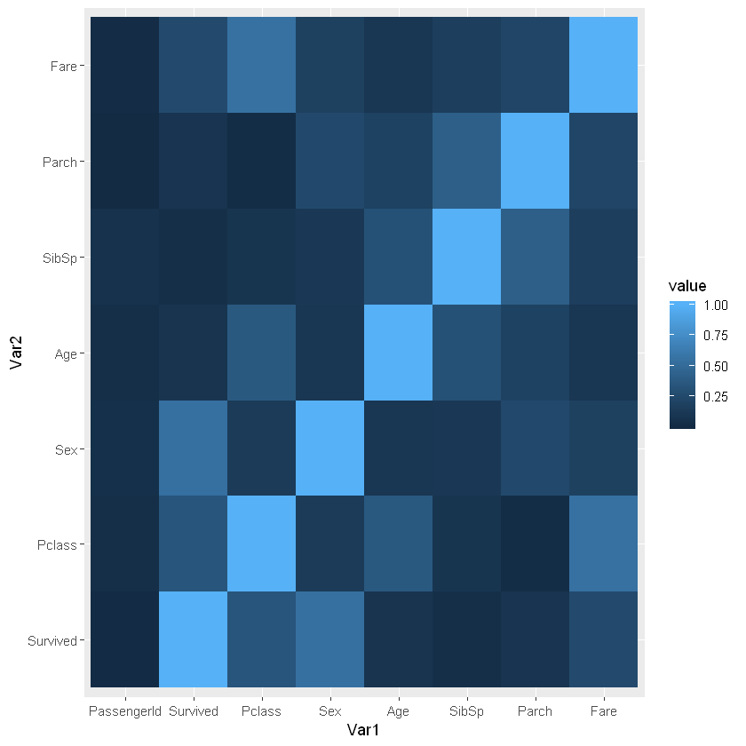

```r
library(ggplot2)

ggplot(data = melted_cormat, aes(x=Var1, y=Var2, fill=value)) +
  geom_tile()
```

```r
# Obtenir le triangle inférieur
  get_lower_tri<-function(cormat){
    cormat[upper.tri(cormat)] <- NA
    return(cormat)
  }
  # Obtenir le triangle supérieur
  get_upper_tri <- function(cormat){
    cormat[lower.tri(cormat)]<- NA
    return(cormat)
  }
```

```r
upper_tri <- get_upper_tri(cormat)
upper_tri
```

|  | PassengerId | Survived | Pclass | Sex | Age | SibSp | Parch | Fare |
| --- | --- | --- | --- | --- | --- | --- | --- | --- |
| PassengerId | 1 | -0.005006661 | -0.03514399 | 0.04293888 | 0.03684720 | -0.05752683 | -0.001652012 | 0.01265822 |
| Survived | NA | 1.000000000 | -0.33848104 | -0.54335138 | -0.07722109 | -0.03532250 | 0.081629407 | 0.25730652 |
| Pclass | NA | NA | 1.00000000 | 0.13190049 | -0.36922602 | 0.08308136 | 0.018442671 | -0.54949962 |
| Sex | NA | NA | NA | 1.00000000 | 0.09325358 | -0.11463081 | -0.245488960 | -0.18233283 |
| Age | NA | NA | NA | NA | 1.00000000 | -0.30824676 | -0.189119263 | 0.09606669 |
| SibSp | NA | NA | NA | NA | NA | 1.00000000 | 0.414837699 | 0.15965104 |
| Parch | NA | NA | NA | NA | NA | NA | 1.000000000 | 0.21622494 |
| Fare | NA | NA | NA | NA | NA | NA | NA | 1.00000000 |

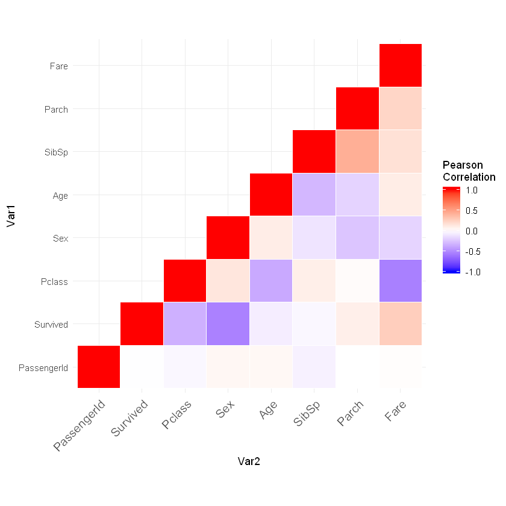

```r
# Fondre la matrice de corrélation
library(reshape2)
melted_cormat <- melt(upper_tri, na.rm = TRUE)
# Heatmap
library(ggplot2)
ggplot(data = melted_cormat, aes(Var2, Var1, fill = value))+
 geom_tile(color = "white")+
 scale_fill_gradient2(low = "blue", high = "red", mid = "white",
   midpoint = 0, limit = c(-1,1), space = "Lab",
   name="Pearson\nCorrelation") +
  theme_minimal()+
 theme(axis.text.x = element_text(angle = 45, vjust = 1,
    size = 12, hjust = 1))+
 coord_fixed()
```

```r
reorder_cormat <- function(cormat){
# Utiliser la corrélation entre les variables
  # comme mésure de distance
dd <- as.dist((1-cormat)/2)
hc <- hclust(dd)
cormat <-cormat[hc$order, hc$order]
}
```

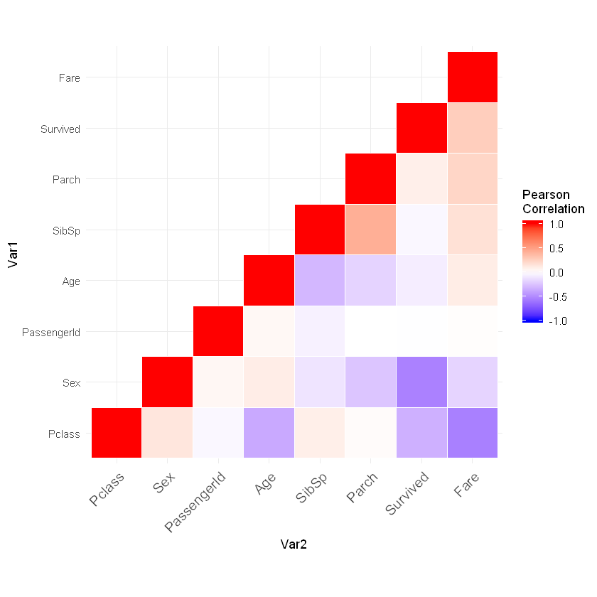

```r
# Reordonner la matrice de corrélation
cormat <- reorder_cormat(cormat)
upper_tri <- get_upper_tri(cormat)
# Fondre la matrice de corrélation
melted_cormat <- melt(upper_tri, na.rm = TRUE)
# Créer un ggheatmap
ggheatmap <- ggplot(melted_cormat, aes(Var2, Var1, fill = value))+
 geom_tile(color = "white")+
 scale_fill_gradient2(low = "blue", high = "red", mid = "white",
   midpoint = 0, limit = c(-1,1), space = "Lab",
   name="Pearson\nCorrelation") +
  theme_minimal()+ # minimal theme
 theme(axis.text.x = element_text(angle = 45, vjust = 1,
    size = 12, hjust = 1))+
 coord_fixed()
# Afficher heatmap
print(ggheatmap)
```

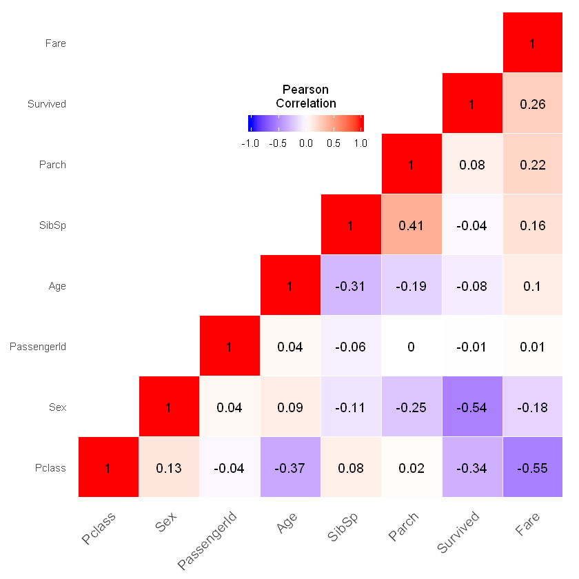

```r
ggheatmap +
geom_text(aes(Var2, Var1, label = round(value,2)), color = "black", size = 4) +
theme(
  axis.title.x = element_blank(),
  axis.title.y = element_blank(),
  panel.grid.major = element_blank(),
  panel.border = element_blank(),
  panel.background = element_blank(),
  axis.ticks = element_blank(),
  legend.justification = c(1, 0),
  legend.position = c(0.6, 0.7),
  legend.direction = "horizontal")+
  guides(fill = guide_colorbar(barwidth = 7, barheight = 1,
                title.position = "top", title.hjust = 0.5))
```

**Question** *comment interprétez vous ce grahe ?*

### Exerise 1: Investiguer les autres variables

Faire un graphe sur le taux de survie des personnes du titanic par la catégorie des personnes qui ont embarqué sur le titanic :

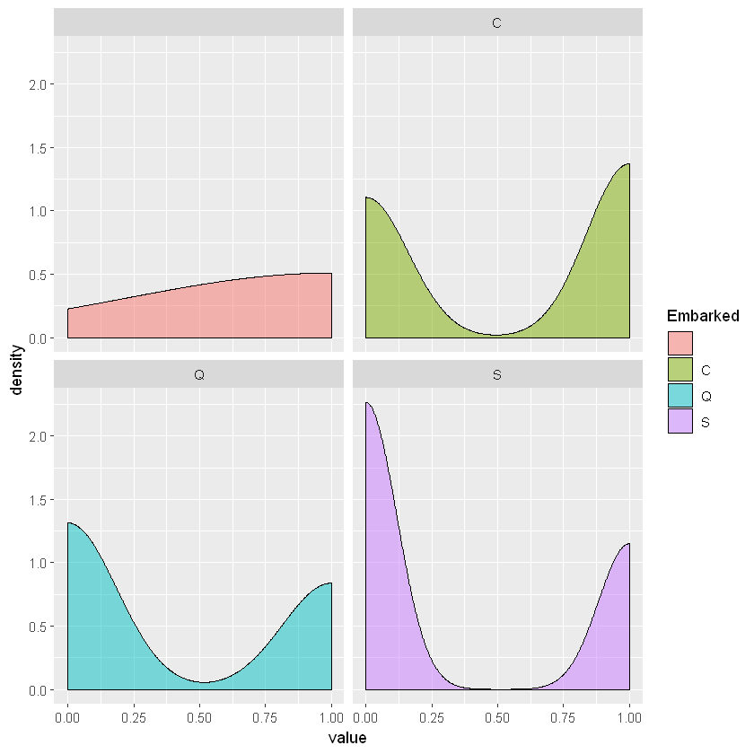

```r
train.m = melt(train[,c("Survived","Embarked")])
ggplot(train.m)+ geom_density( aes(x = value,fill=Embarked),alpha=0.5)+ facet_wrap(~Embarked)
```

- C = Cherbourg
- Q = Queenstown
- S = Southampton

**Question** *créer un graphe de la survie ou non des passagers en fonction de la variable fare en s'aidant de l'exemple au dessus*

**Question** *créer un graphe de la survie ou non des passagers en fonction du genre*

**Question** *créer un graphe de la survie ou non des passagers en fonction de Pclass*

**Question** *créer un graphe de la survie ou non des passagers en fonction de SibSp*

**Question** *créer un graphe de la survie ou non des passagers en fonction de parch*

### Exercice 2 : créer de nouvelles variables

Deux variables permettent de créer une nouvelle variable afin d'ajouter et de créer une variable explicative "la taille de la famille"

```r
### ajout d'une variable supplémentaire au problème

train$Family_Size <- train$Parch +train$SibSp +1
```

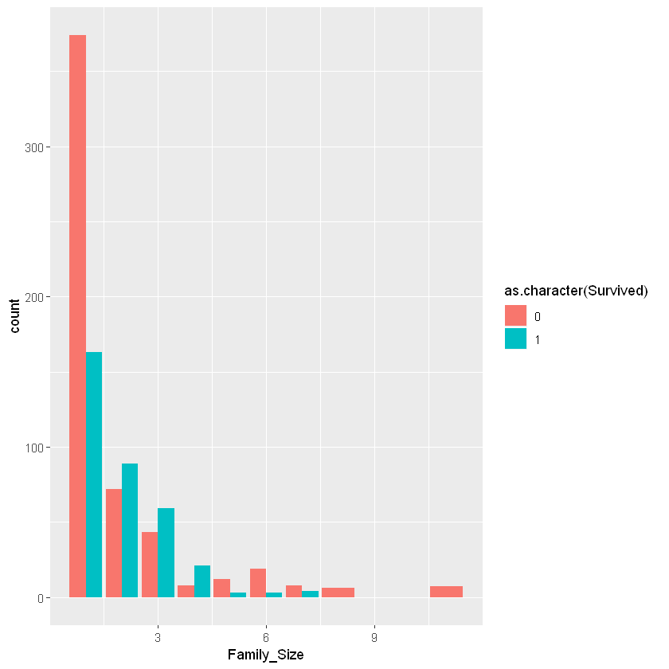

```r
ggplot(train)+ geom_bar(aes(x=Family_Size,fill=as.character(Survived)),position="dodge")
```

**Question** *en l'état on peut remarquer que la taille famille peut être classer en groupe plus pertinant comme variable explicative. Trouver les.*

Nous avons d'autres variables explicatives où nous pouvons extraire de l'information.

**Question** *Essayer de créer d'autres variables explicatives pour le modèle de prédiction de survie d'un passager*

### Prédiction

Nous avons enfin explorer les données de problèmes afin de créer un modéle statistique de survie des passages du Titanic.

Partager les données en train un jeux de données de test et un jeux de données d'entrainement.

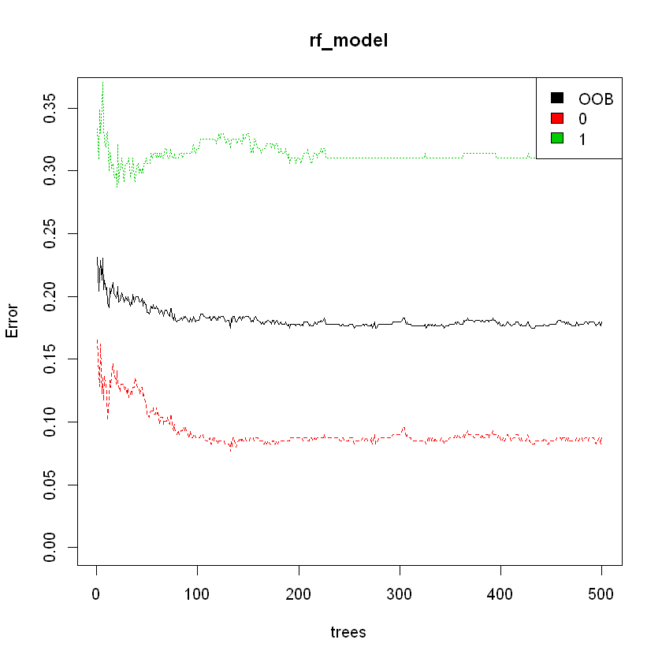

```r
train_mat <- train [1:799,]
test <- train[800:891,]

train_mat = train_mat[complete.cases(train_mat),] %>% filter(Embarked %in%c("C","S","Q"))


# construire le modèle

rf_model <- randomForest(factor(Survived) ~  Sex + Age + Pclass+Fare,
                                            data = train_mat)

# Show model error
plot(rf_model, ylim=c(0,0.36))
legend('topright', colnames(rf_model$err.rate), col=1:3, fill=1:3)
```

La courbe noire informe de l'erreur total qui est à environ 20%. La rouge et la verte correspond respectivement à l'erreur de prédiction de la mort d'un passager et l'erreur de survie d'un passager à bord du titanic.

### Importance des variables

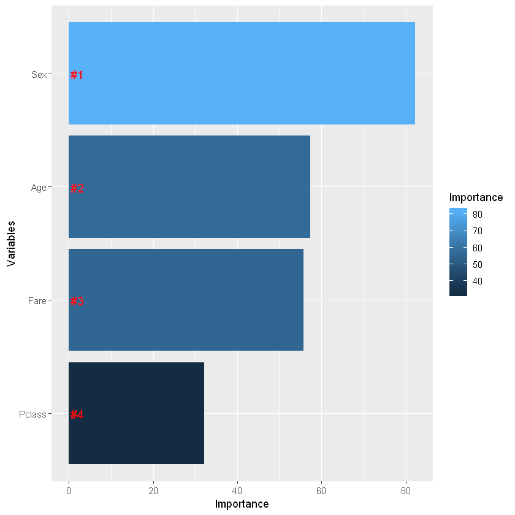

```r
# Get importance
importance    <- importance(rf_model)
varImportance <- data.frame(Variables = row.names(importance),
                            Importance = round(importance[ ,'MeanDecreaseGini'],2))

# Create a rank variable based on importance
rankImportance <- varImportance %>%
  mutate(Rank = paste0('#',dense_rank(desc(Importance))))

# Use ggplot2 to visualize the relative importance of variables
ggplot(rankImportance, aes(x = reorder(Variables, Importance),
    y = Importance, fill = Importance)) +
  geom_bar(stat='identity') +
  geom_text(aes(x = Variables, y = 0.5, label = Rank),
    hjust=0, vjust=0.55, size = 4, colour = 'red') +
  labs(x = 'Variables') +
  coord_flip()
```

### Backtesting: Leonardo di Caprio died or not ?

L'étape de backtesting est la plus importante. Elle permet de montrer la performance de votre modèle de ML. Nous avons séparé le jeux de données que nous utilisons en un jeu de données de tests et un jeu de données d'entraînement.

```r
test <- test[complete.cases(test),]
prediction <- predict(rf_model, test)
test$prediction <- prediction
```

[output not shown]

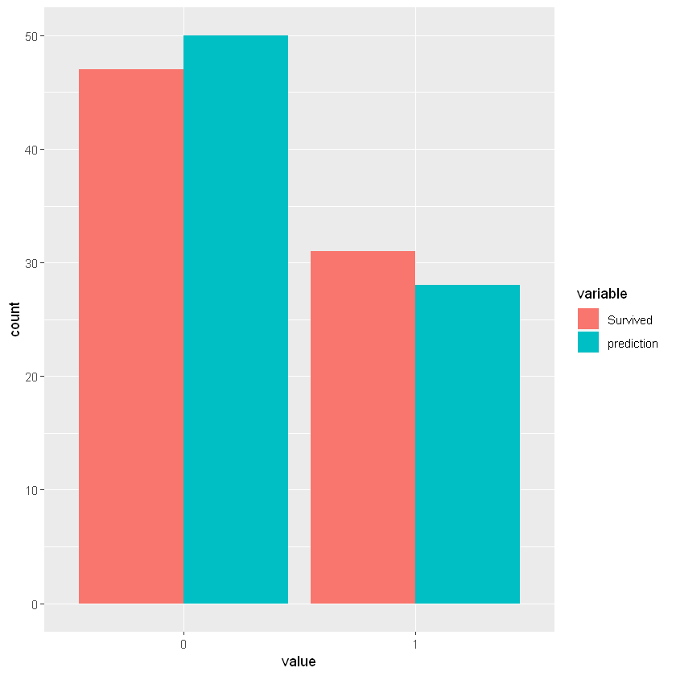

```r
test.m = reshape2::melt(test %>% select(PassengerId,Survived,prediction),id.vars = "PassengerId")
head(test.m)
ggplot(test.m)+geom_bar(aes(x = value,fill=variable),position="dodge")
```

```r
nrow(test)
```

78

**Question** Simuler si les acteurs de titanic survivent ou pas ?

```r
test_leo = test[1,]
test_leo$Survived = 0
test_leo$Pclass = 3
test_leo$Name = "Leo"
test_leo$Sex = 2
test_leo$Age =20
test_leo$Fare =100

test_kate = test[1,]

test_kate$Survived = 1
test_kate$Pclass = 1
test_kate$Name = "Kate"
test_kate$Sex = 1
test_kate$Age =20
test_kate$Fare =7500


# kate
 predict(rf_model, test_kate)
# leo
 predict(rf_model, test_leo)
```

**800:** 1

**Levels**:**

1. '0'

2. '1'

**800:** 0

**Levels**:**

1. '0'

2. '1'